# Wind speed analysis

*Raynaldi Pratama*

07/03/2021

**Notes:** This portfolio presents a short analysis of the extreme event of wind speed occurrence at Bilbao-Vizcaya buoy location. The reference location was selected based on the available dataset used in two previous portfolios, i.e., [wind resource assessment](https://rpubs.com/raynaldiprtm/data-anavis-01) and [wind rose plot](https://rpubs.com/raynaldiprtm/data-anavis-02).

**Library setup:**

```r
# Working with table
library(kableExtra)

# Extreme values
library(ismev)
library(evir)
```

## Bilbao-Vizcaya buoy data

### Load the data

```r
buoydata <- read.table("BilbaoVizcaya.txt", header = TRUE)

kbl(summary(buoydata)) %>%
  kable_paper() %>%
  scroll_box(width = "100%", height = "300px")
```

|  | AA | MM | DD | HH | Hm0 | Tm02 | Tp | Hmax | Thmax | Pro_Oe | Dmd | Dmd_P | Ds_P | Pro_Od | Ts2 | Sa2 | Vc_md | Dc_md | Pro_Oce | Ps | Ta | Vv_md | Dv_md | Pro_Met | Qc_e |
| --- | --- | --- | --- | --- | --- | --- | --- | --- | --- | --- | --- | --- | --- | --- | --- | --- | --- | --- | --- | --- | --- | --- | --- | --- | --- |
|  | Min. :1990 | Min. : 1.000 | Min. : 1.00 | Min. : 0.00 | Min. : 0.000 | Min. : 0.000 | Min. : 0.000 | Min. : 0.000 | Min. : 0.000 | Min. :1.000 | Min. : 0.0 | Min. : 0.0 | Min. :10.00 | Min. :0.000 | Length:116714 | Length:116714 | Length:116714 | Length:116714 | Min. :0.00 | Min. : 965 | Min. : 0.00 | Min. : 0.000 | Min. : 0.0 | Min. :0.000 | Min. :1.000 |
|  | 1st Qu.:2004 | 1st Qu.: 4.000 | 1st Qu.: 8.00 | 1st Qu.: 5.00 | 1st Qu.: 1.100 | 1st Qu.: 4.800 | 1st Qu.: 8.000 | 1st Qu.: 1.600 | 1st Qu.: 7.300 | 1st Qu.:1.000 | 1st Qu.:294.0 | 1st Qu.:294.0 | 1st Qu.:24.00 | 1st Qu.:1.000 | Class :character | Class :character | Class :character | Class :character | 1st Qu.:0.00 | 1st Qu.:1012 | 1st Qu.:12.50 | 1st Qu.: 2.900 | 1st Qu.: 90.0 | 1st Qu.:2.000 | 1st Qu.:1.000 |
|  | Median :2007 | Median : 7.000 | Median :16.00 | Median :12.00 | Median : 1.600 | Median : 5.800 | Median : 9.800 | Median : 2.300 | Median : 9.300 | Median :1.000 | Median :306.0 | Median :304.0 | Median :30.00 | Median :1.000 | Mode :character | Mode :character | Mode :character | Mode :character | Median :2.00 | Median :1017 | Median :15.50 | Median : 4.900 | Median :196.0 | Median :2.000 | Median :1.000 |
|  | Mean :2006 | Mean : 6.675 | Mean :15.76 | Mean :11.33 | Mean : 1.882 | Mean : 6.074 | Mean : 9.582 | Mean : 2.864 | Mean : 9.283 | Mean :1.057 | Mean :286.7 | Mean :288.8 | Mean :32.22 | Mean :1.142 | NA | NA | NA | NA | Mean :1.26 | Mean :1017 | Mean :15.51 | Mean : 5.183 | Mean :189.5 | Mean :1.977 | Mean :1.143 |
|  | 3rd Qu.:2011 | 3rd Qu.: 9.000 | 3rd Qu.:23.00 | 3rd Qu.:18.00 | 3rd Qu.: 2.300 | 3rd Qu.: 7.100 | 3rd Qu.:11.100 | 3rd Qu.: 3.600 | 3rd Qu.:11.200 | 3rd Qu.:1.000 | 3rd Qu.:319.0 | 3rd Qu.:315.0 | 3rd Qu.:39.00 | 3rd Qu.:1.000 | NA | NA | NA | NA | 3rd Qu.:2.00 | 3rd Qu.:1022 | 3rd Qu.:19.10 | 3rd Qu.: 7.000 | 3rd Qu.:286.0 | 3rd Qu.:2.000 | 3rd Qu.:1.000 |
|  | Max. :2014 | Max. :12.000 | Max. :31.00 | Max. :23.00 | Max. :13.700 | Max. :14.400 | Max. :22.300 | Max. :22.600 | Max. :25.600 | Max. :3.000 | Max. :360.0 | Max. :360.0 | Max. :81.00 | Max. :3.000 | NA | NA | NA | NA | Max. :3.00 | Max. :1114 | Max. :29.30 | Max. :23.800 | Max. :360.0 | Max. :3.000 | Max. :9.000 |
|  | NA | NA | NA | NA | NA’s :1219 | NA’s :1223 | NA’s :1219 | NA’s :4113 | NA’s :4113 | NA | NA’s :11742 | NA’s :10326 | NA’s :15143 | NA | NA | NA | NA | NA | NA | NA’s :10124 | NA’s :5552 | NA’s :11577 | NA’s :22733 | NA | NA |

### Annual maximum wind speed

The vector of annual maximum wind speed will be retrieved from Bilbao-Vizcaya buoy data. In this case, the exclusion applied from 1997 and the years before, since in 1997, there is no wind speed recorded data at all (equals “NAN”). Additionally, the year 2014 will also be excluded as there are only two months of data that doesn’t represent the whole year observations.

```r
windSpeedMax <- c()

for (i in 1998:2013) {
  year <- which(buoydata$AA == i)
  windSpeedMax[i - 1997] <- max(buoydata[year, 22], na.rm = TRUE)
}

windSpeedMax # Annual max win speeds from 1998 to 2013 at 3 m height
```

```
##  [1] 23.0 22.1 23.8 16.8 17.0 17.9 17.3 17.8 23.6 17.8 19.2 23.6 19.6 16.1 18.7
## [16] 18.7
```

### **`windSpeedMax`** at 70 m height

```r
windSpeedMax70 <- windSpeedMax * log(70 / 0.0005) / log(3 / 0.0005)

windSpeedMax70 # Annual max win speeds from 1998 to 2013 at 70 m height
```

```
##  [1] 31.32774 30.10187 32.41740 22.88287 23.15529 24.38116 23.56391 24.24495
##  [9] 32.14499 24.24495 26.15185 32.14499 26.69668 21.92942 25.47082 25.47082
```

## GEV distribution fit

```r
fit <- gev.fit(windSpeedMax70)
```

```r
# Negative (maximised) log–likelihood
fit$nllh
```

```
## [1] 41.60161
```

```r
# Maximum likelihood estimates for µ, s and s respectively
fit$mle[1] # µ (location)
```

```
## [1] 24.67838
```

```r
fit$mle[2] # s (scale)
```

```
## [1] 2.44868
```

```r
fit$mle[3] # s (shape)
```

```
## [1] 0.2170222
```

```r
# Associated standard errors for the above parameters
fit$se
```

```
## [1] 0.7482476 0.6165813 0.2978576
```

## Expected max wind speeds

Below are the results showing 10, 20, 30, 40, 50, 70, 100 years expected maximum wind speeds with the limit of central value at 95% confidence level.

```r
gevdistr <- gev(windSpeedMax70)

matA <- matrix(NaN, nrow = 7, ncol = 4) # Empty matrix

years <- c(10, 20, 30, 40, 50, 70, 100)

matA[, 1] <- years

for (i in 1:7) {
  matA[i, 2:4] <- rlevel.gev(gevdistr, years[i],
    add = FALSE,
    xlab = "Return level",
    ylab = "Profile log–likelihood"
  )
}
```

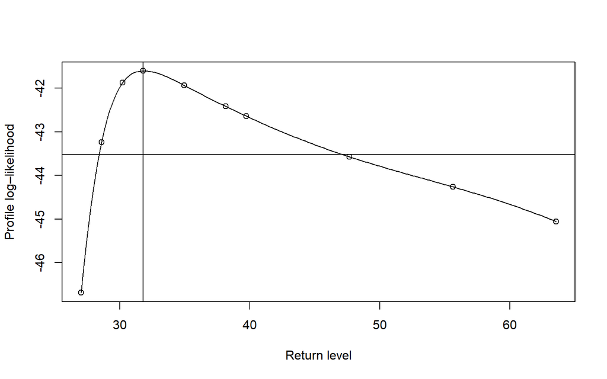

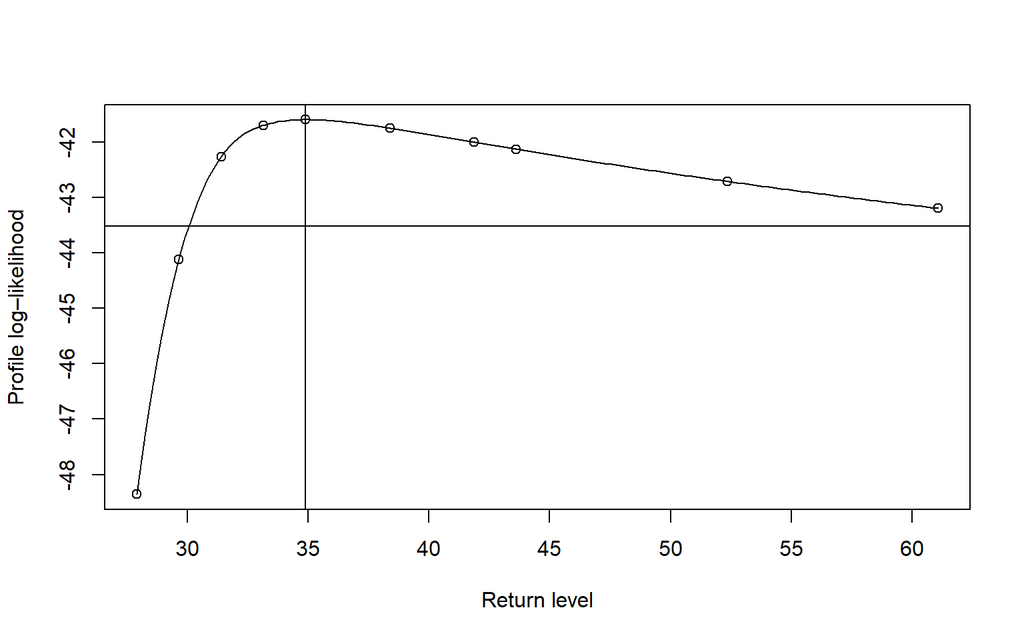

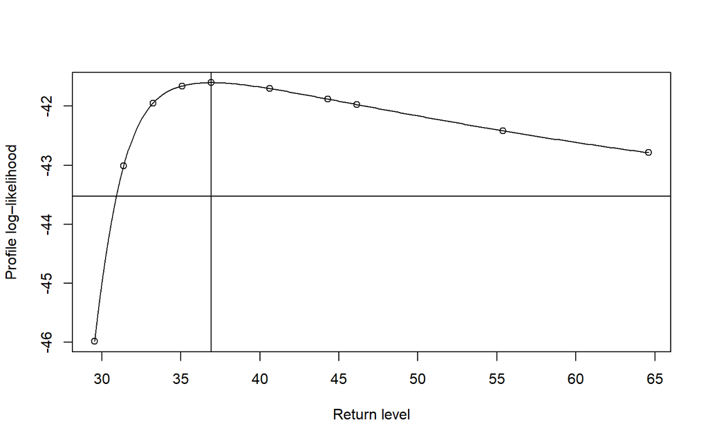

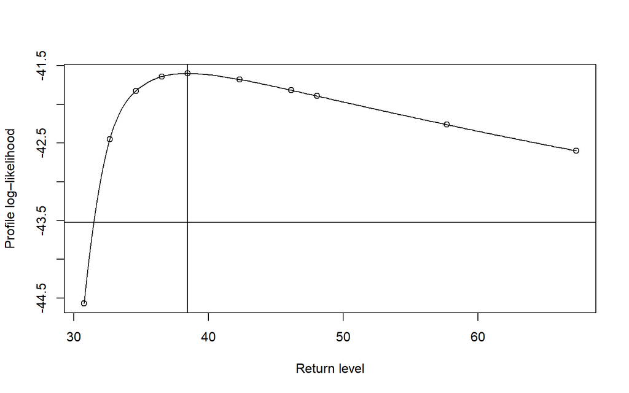

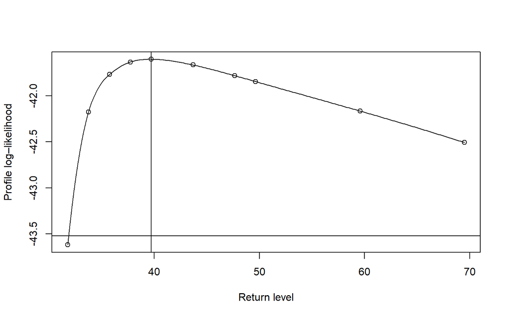

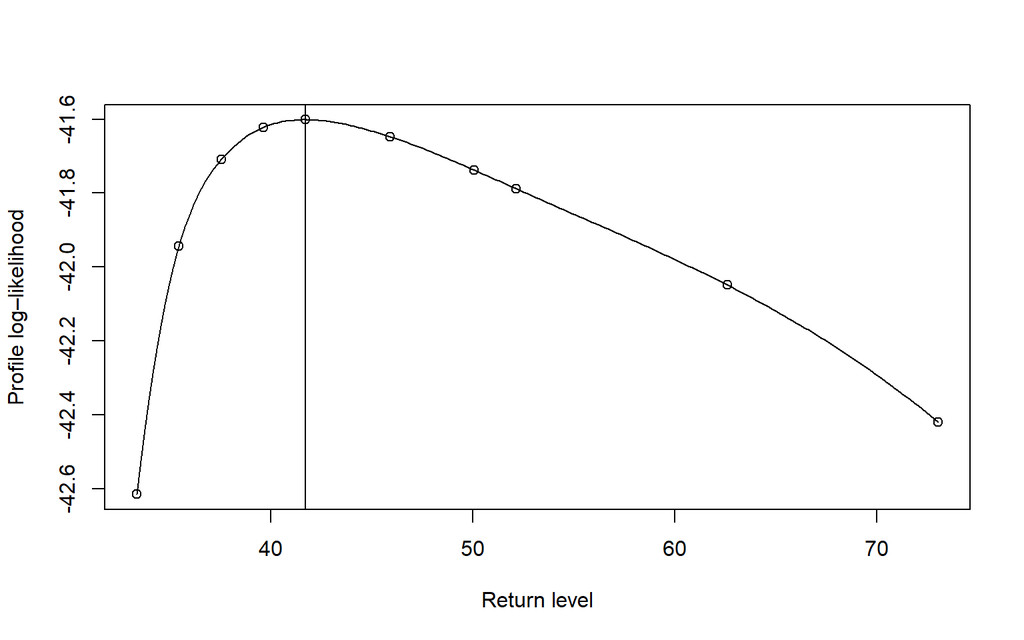

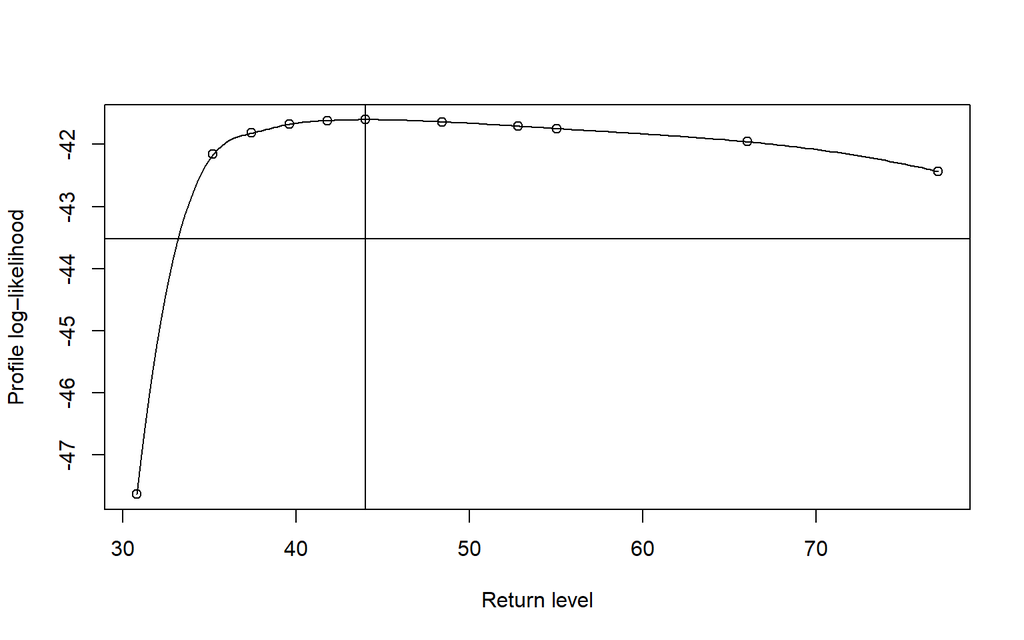

```r
matA # Matrix A is presented without proper column names
```

```
##      [,1]     [,2]     [,3]     [,4]
## [1,]   10 28.48495 31.78304 47.03571
## [2,]   20 30.07907 34.89208 61.06114
## [3,]   30 30.94051 36.91343 64.59851
## [4,]   40 31.49567 38.45177 67.29059
## [5,]   50 31.95724 39.70959 69.49178
## [6,]   70 33.37665 41.72082 73.01143
## [7,]  100 33.36504 44.01487 77.02602
```

```r
rownames(matA) <- c("1", "2", "3", "4", "5", "6", "7")

colnames(matA) <- c(
  "n-years",
  "Lower limit",
  "Central value",
  "Upper limit"
)

matA # All values are in m/sec
```

```
##   n-years Lower limit Central value Upper limit
## 1      10    28.48495      31.78304    47.03571
## 2      20    30.07907      34.89208    61.06114
## 3      30    30.94051      36.91343    64.59851
## 4      40    31.49567      38.45177    67.29059
## 5      50    31.95724      39.70959    69.49178
## 6      70    33.37665      41.72082    73.01143
## 7     100    33.36504      44.01487    77.02602
```

## Extreme operating gust

Before estimating the extreme operating gust, the SD (standard deviation) of the turbulence in the longitudinal average wind direction has to be calculated. It is assumed that the turbulence intensity is 0.16 (higher turbulence characteristics as determined in the standard). The following formula is used to calculate the standard deviation based on international standard IEC 61400-1:

$$\sigma_x = I_{ref}(0.75U_{hub}+5.6)$$

Where, $I_{ref}$ is expected value of hub-height turbulence intensity at a 10 min average wind speed of 15 m/s.

### Average wind speed

```r
windSpeedAvg <- c()

for (i in 1998:2013) {
  year <- which(buoydata$AA == i)
  windSpeedAvg[i - 1997] <- mean(buoydata[year, 22], na.rm = TRUE)
}

windSpeedAvg # Annual average win speeds from 1998 to 2013 at 3 m height
```

```
##  [1] 6.432717 6.393928 5.858981 5.902472 5.340878 5.256232 5.821496 5.392806
##  [9] 5.317522 4.859059 5.072242 5.196041 5.544258 4.754791 4.742348 5.076796
```

### **`windSpeedAvg`** at 70 m height

```r
windSpeedAvg70 <- windSpeedAvg * log(70 / 0.0005) / log(3 / 0.0005)

windSpeedAvg70 # Annual average win speeds from 1998 to 2013 at 70 m height
```

```
##  [1] 8.761847 8.709014 7.980375 8.039614 7.274680 7.159386 7.929319 7.345410
##  [9] 7.242867 6.618407 6.908777 7.077402 7.551700 6.476385 6.459437 6.914981
```

### Standard deviation

```r
Iref <- 0.16

Uhub <- mean(windSpeedAvg70)

SD <- Iref * (0.75 * Uhub + 5.6)

SD
```

```
## [1] 1.784372
```

### IEC 50-year gust

```r
D <- 92 # Blade diameter in m

Ugust50 <- 6.4 * (SD / (1 + (0.1 * D / 21)))

Ugust50
```

```
## [1] 7.941046
```

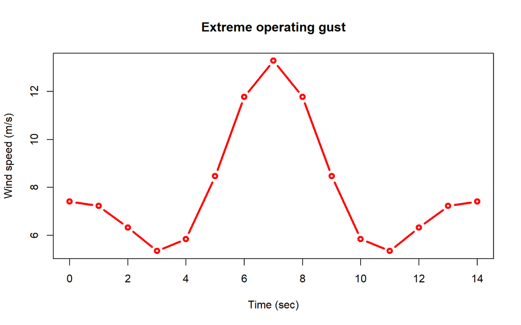

```r
T <- 14 # Time in sec

Ut <- c()

for (t in 0:15) {
  Ut[t] <- Uhub - 0.37 * Ugust50 *
    sin((3 * pi * (t - 1)) / T) *
    (1 - cos((2 * pi * (t - 1)) / T))
}

sec <- seq(0, 14, by = 1) # Time in sec

plot(sec, Ut,
  type = "b", lwd = 3, col = "red",
  xlab = "Time (sec)",
  ylab = "Wind speed (m/s)",
  main = "Extreme operating gust"
)
```